# Application of machine learning algorithms to weightlifting sensor data

Alex Gaggin

November 18, 2015

### Summary

In this research a dataset of sensor readings from subjects performing a weightlifting exercise in correct and flawed techniques is analyzed. The goal is to see if machine learning algorithms can be used to recognize exercise techniques based on sensor data. It’s shown that Random Forest training algorithm with out-of-bag resampling method produces the best results both in predictiona accuracy and training time. After reducing dataset to 52 original sensor reading predictors and training with 500 trees, validation on out-of-sample group of data point resulted in 99.52% prediction accuracy (95% confidence interval for prediction accuracy is 99.24-99.71% - better than accuracy listed in original research paper on this dataset, which was 98.03%).

This exercise was also done to perform prediction as an assignment in Practical Machine Learning class in Data Science specialization on Coursera. Assignment’s testing dataset included not just the sensor readings, but also an observation id that allows to calculate outcomes without using machine learning. These outcomes were also used for verification of machine learning predictions based on sensors, and they match ideally.

### Exploratory analysis

[A dataset](http://groupware.les.inf.puc-rio.br/har) (see Appendix 1) analyzed in this paper includes sensor data from six subjects executing same weightlifting excersize in five styles, only one of which is correct. It’s shown how machine learning can be used two interpret sensor data to recognize exercise styles. Practical application for this kind of technology would be a programmatic trainer that advises a trainee to correct their exercise form. This particular paper though is done as a course project for Practical Machine Learning class in Data Science specialization on Coursera and is focused on applying machine learning methods to the dataset.

We download the training dataset and split it to three parts - 60% training, 20% development test, 20% validation of out-of-sample error. The model selection work will be done with training and test parts, and then once model approach is settled, the algorithm will be trained on merged train and test subsets and checked against validation subset (set aside until that point) to assess out-of-sample prediction accuracy.

```r
remote <- "https://d396qusza40orc.cloudfront.net/predmachlearn/pml-training.csv"
dl.read <- function(remote) {
        loc <- basename(remote)
        if(!file.exists(loc )) download.file(remote, loc)
        read.csv(loc)}
working <- dl.read(remote)
set.seed(1000)
inTrain  <- createDataPartition(working$classe, p = 0.6, list=FALSE)
training <- working[inTrain, ]
nontraining <- working[-inTrain, ]
inTest <- createDataPartition(nontraining$classe, p = 0.5, list=FALSE)
testing  <- nontraining[inTest, ]
validating  <- nontraining[-inTest, ]
dim(working)
```

```
## [1] 19622   160
```

```r
dim(training)
```

```
## [1] 11776   160
```

```r
dim(testing)
```

```
## [1] 3923  160
```

```r
dim(validating)
```

```
## [1] 3923  160
```

But visually reviewing data via View(), it can be seen that the data is grouped to windows identified by common “num_window” variable where the last entry has new_window==yes and then it has more non-empty variables associated with it then observations with new_window==no.These ones have a lot of NAs, and “Div/0!”, and empty values instead.

We select a short example of the data to illustrate this structure here. We keep in mind that in the training set some rows are taken out for verification sub-sets while selecting it, and remember that so the actual window is probably longer, and there are more variables that shown in the example.

```r
finished <- training[training$new_window == "yes", "num_window"]
have.prev <- finished[((finished-1) %in% finished)]
length <- training[training$num_window %in% have.prev,
                                "num_window"] %>% table %>% .[.>1] %>% "["(1)
last.obs <- training %>% with(new_window == "yes" &
                                      num_window == names(length)) %>% which
range.obs <- (last.obs - length - 1):(last.obs + 1)
training[range.obs,c(6,7,8,12,18,160)]
```

```
##    new_window num_window roll_belt kurtosis_roll_belt max_roll_belt classe
## 51         no         13      1.29                               NA      A
## 52        yes         13      1.27          -0.997130         -94.1      A
## 53         no         14      1.26                               NA      A
## 55         no         14      1.26                               NA      A
## 57         no         14      1.25                               NA      A
## 58         no         14      1.23                               NA      A
## 60         no         14      1.25                               NA      A
## 61         no         14      1.26                               NA      A
## 62         no         14      1.26                               NA      A
## 65         no         14      1.28                               NA      A
## 67         no         14      1.23                               NA      A
## 68         no         14      1.20                               NA      A
## 70         no         14      1.16                               NA      A
## 71         no         14      1.15                               NA      A
## 72         no         14      1.16                               NA      A
## 74         no         14      1.19                               NA      A
## 75         no         14      1.18                               NA      A
## 76        yes         14      1.18           7.515290         -94.1      A
## 79         no         15      1.14                               NA      A
```

Because they go last, we assume that the last observation in each window contains some aggregate information for the whole window. Variable names agree to this assumption. Supposedly actual application (programmatic trainer) could rely on this aggregates for decisions, but for the purpose of this paper we ignore these additional variables and will only keep ones that have values for every observation.

By the way, all variables of each window are identified as the same class (calculation to verify this statement is shown below). Apparently, because each window is an example of particular weightlifting exercise form.

```r
# A cross table of window number vs response class, only one class for each
# window has values, and four others are zeroes.
training$num_window %>% table(training$classe) %>% "=="(0) %>% rowSums %>%
        "!="(4) %>% sum
```

```
## [1] 0
```

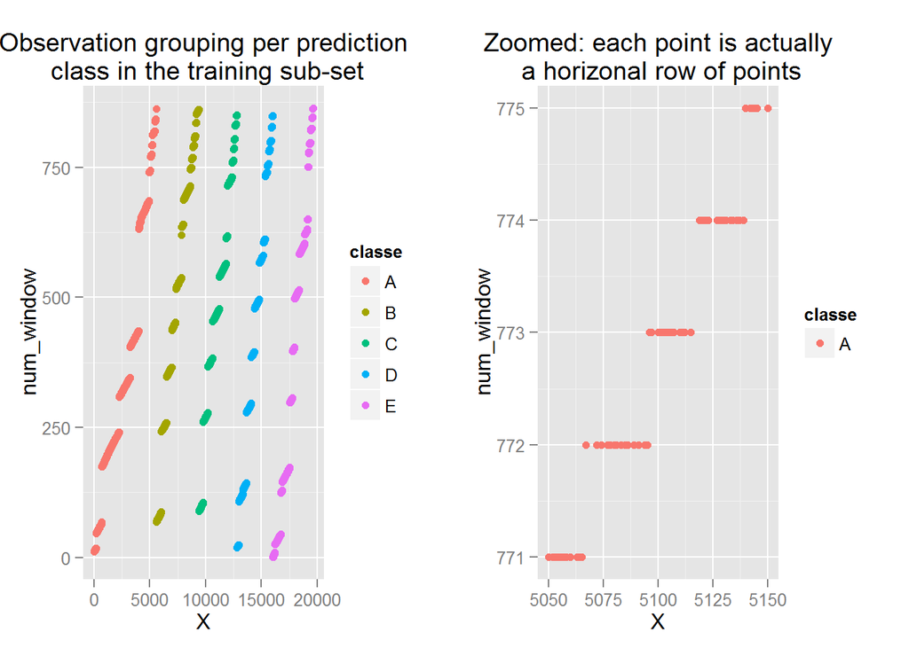

```r
larger <- training %>% with(qplot(X, num_window, color=classe,
    main="Observation grouping per prediction\n class in the training sub-set"))
smaller <- training[training$X %in% 5050:5150, ] %>%
    with(qplot(X, num_window, color=classe,
    main="Zoomed: each point is actually\n a horizonal row of points"))
grid.arrange(larger, smaller, ncol=2)
```

Thus, as Coursera’s assignment provides in its testing set the num_window variable for the same users in the same range (so, from the same experiment), we can get answers without using machine learning, but with direct lookup by window number instead. We get these with the goal to use them as verification for machine learning predictions based on sensor data.

```r
remote <- "https://d396qusza40orc.cloudfront.net/predmachlearn/pml-testing.csv"
assignment <- dl.read(remote)
# We use the full original training data set just in case of caret completely
# missing some window in the training sample after partition
classe.by.window <- function(window) {
        working$classe[which(working$num_window == window)[1]]}
(answers <- sapply(assignment$num_window,classe.by.window))
```

```
##  [1] B A B A A E D B A A B C B A E E A B B B
## Levels: A B C D E
```

### Data cleanup

We now also remove non-sensor measurements: line numbers, user names, timestamps and window markers, and aggreate variables. We are left with 52 predictor variables.

```r
nas<-sapply(training, function(x) sum(is.na(x) | x == "" | x == "#DIV/0!"))
trainingNotNA<-training[,names(nas[nas == 0])]
tr<-trainingNotNA[,-(1:7)]
dim(tr)
```

```
## [1] 11776    53
```

### Training with Recursive Partitioning

Because we have categorical outcomes, we can’t use linear models, but turn to classification trees instead. We try to build simple decision tree and see that it fails to provide a prediction much better than a coin flip. We use accuracy rate and training time as two parameters we are interested in.

```r
set.seed(1)
system.time(
        confusionMatrix(
                predict(train(classe~., data=tr, method="rpart"), testing),
                testing$classe)$overall[1] %>% print)
```

```
##  Accuracy
## 0.5597757
```

```
##    user  system elapsed
##   15.72    0.19   15.94
```

### Training with Random Forest

As simple tree failed, we now try to use Random Forest as an algorithm that is known for prediction accuracy. Because it’s also known to be slow, we first try it with low number of trees to speed the check up. We see that accuracy is quite high, and so with higher number of trees we expect to get result close to the benchmark.

```r
set.seed(1)
try.rf <- function(ctl, trees=5) {
        system.time(
                mod <- train(classe~., data=tr, method="rf",
                             ntree=trees, trControl=ctl)) %>% print
        confusionMatrix(predict(mod, testing),
                        testing$classe)$overall[1] %>% print
        return(mod)
        }
trainControl() %>% try.rf -> mod5
```

```
##    user  system elapsed
##   46.90    0.28   47.31
##  Accuracy
## 0.9714504
```

### Optimizing resampling for the Random Forest

Before running the long training, we try to optimize different parameters for train control. For the speed, we keep number of trees low. We realize that we don’t know if the comparison results depend on number of trees, but for the speed we presume they are.

After running tests with various train control methods, we find “repeatedcv”, “adaptive_boot”, and “adaptive_LGOCV” methods to work better than others in terms of accuracy/speed balance, but the best method is “out-of-bag” - it provides good accuracy, while being dramatically faster, and its accuracy to increase in number of trees stronger. Particular measurements are shown in Appendix 2.

### Optimizing by reduction of predictors

We try to improve accuracy/speed balance by reducing number of predictors in three ways: by using Principal Component Analysis, by manually selecting predictors most correlated with outcomes, and by modeling by each of four sensors separately. See Appendix 3 for the code. Neither of these leads to improvement, so we infer that all sensors are needed to correcly identify exercise techniques.

### Building final model

We now merge training and testing subsets, and then use this wider dataset to train the final model with Random Forest at high number of trees and with previously found cross-validation parameters (oob). We apply then resulting model to validation dataset to infer out-of-sample accuracy assessment.

```r
training2 <- rbind(training, testing)
nas2 <- sapply(training2, function(x) sum(is.na(x) | x == "" | x == "#DIV/0!"))
trainingNotNA2 <- training2[, names(nas2[nas2 == 0])]
tr2 <- trainingNotNA2[, -(1:7)]

set.seed(1)
system.time(
        mod500oob <- train(classe~., data=tr2, method="rf",
                        ntree=500, trControl=trainControl(method="oob"))
                        ) %>% print
```

```
##    user  system elapsed
##  291.64    0.87  293.11
```

```r
confusionMatrix(predict(mod500oob,validating),validating$classe)
```

```
## Confusion Matrix and Statistics
##
##           Reference
## Prediction    A    B    C    D    E
##          A 1116    7    0    0    0
##          B    0  752    2    1    0
##          C    0    0  677    3    1
##          D    0    0    5  639    0
##          E    0    0    0    0  720
##
## Overall Statistics
##
##                Accuracy : 0.9952
##                  95% CI : (0.9924, 0.9971)
##     No Information Rate : 0.2845
##     P-Value [Acc > NIR] : < 2.2e-16
##
##                   Kappa : 0.9939
##  Mcnemar's Test P-Value : NA
##
## Statistics by Class:
##
##                      Class: A Class: B Class: C Class: D Class: E
## Sensitivity            1.0000   0.9908   0.9898   0.9938   0.9986
## Specificity            0.9975   0.9991   0.9988   0.9985   1.0000
## Pos Pred Value         0.9938   0.9960   0.9941   0.9922   1.0000
## Neg Pred Value         1.0000   0.9978   0.9978   0.9988   0.9997
## Prevalence             0.2845   0.1935   0.1744   0.1639   0.1838
## Detection Rate         0.2845   0.1917   0.1726   0.1629   0.1835
## Detection Prevalence   0.2863   0.1925   0.1736   0.1642   0.1835
## Balanced Accuracy      0.9988   0.9949   0.9943   0.9961   0.9993
```

Comparison to answers derived from num_window shows full match.

```r
confusionMatrix(predict(mod500oob, assignment), answers)$overall[1]
```

```
## Accuracy
##        1
```

We check the most importent predictors as identified by the final model and see that they don’t fully match the list of the most correlated in Appendix 3.

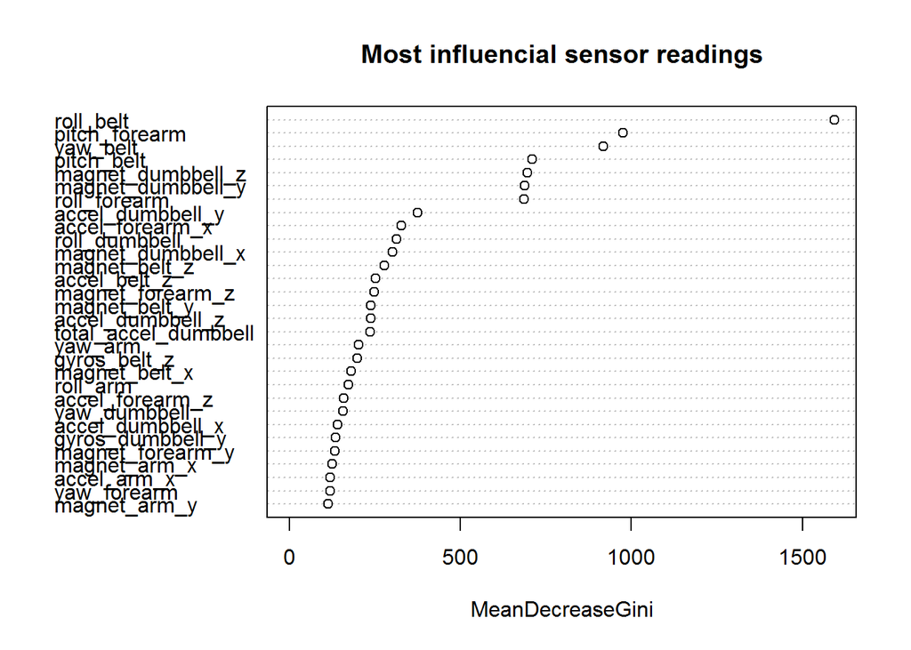

```r
varImpPlot(mod500oob$finalModel, main="Most influencial sensor readings")
```

### Appendices

#### Appendix 1. References

Dataset source is  
Velloso, E.; Bulling, A.; Gellersen, H.; Ugulino, W.; Fuks, H. [Qualitative Activity Recognition of Weight Lifting Exercises](http://groupware.les.inf.puc-rio.br/work.jsf?p1=11201). Proceedings of 4th International Conference in Cooperation with SIGCHI (Augmented Human ’13) . Stuttgart, Germany: ACM SIGCHI, 2013.

#### Appendix 2. Trials of various resampling methods

```r
set.seed(1)
trainControl(method="repeatedcv", number=5, repeats=2) %>% try.rf -> mod5rcv5.2
```

```
##    user  system elapsed
##   15.48    0.22   15.72
## Accuracy
##  0.97247
```

```r
set.seed(1)
trainControl(method="repeatedcv", number=10, repeats=2) %>% try.rf -> mod5rcv10.2
```

```
##    user  system elapsed
##   33.55    0.31   33.86
##  Accuracy
## 0.9773133
```

```r
set.seed(1)
trainControl(method="repeatedcv", number=5, repeats=5) %>% try.rf -> mod5rcv5.5
```

```
##    user  system elapsed
##   37.08    0.12   37.21
##  Accuracy
## 0.9732348
```

```r
set.seed(1)
trainControl(method="repeatedcv", number=20, repeats=2) %>% try.rf -> mod5rcv20.2
```

```
##    user  system elapsed
##   70.08    0.00   70.09
##  Accuracy
## 0.9739995
```

```r
set.seed(1)
trainControl(method="cv", number=5) %>% try.rf -> mod5cv5
```

```
##    user  system elapsed
##    8.30    0.00    8.29
##  Accuracy
## 0.9719602
```

```r
set.seed(1)
trainControl(method="oob") %>% try.rf -> mod5oob
```

```
##    user  system elapsed
##    2.90    0.00    2.91
##  Accuracy
## 0.9729799
```

```r
set.seed(1)
trainControl(method="boot632") %>% try.rf -> mod5b6
```

```
##    user  system elapsed
##   48.36    0.02   48.38
##  Accuracy
## 0.9722151
```

```r
set.seed(1)
trainControl(method="adaptive_boot") %>% try.rf -> mod5ab
```

```
##    user  system elapsed
##   22.58    0.00   22.58
##  Accuracy
## 0.9778231
```

```r
set.seed(1)
trainControl(method="adaptive_cv") %>% try.rf -> mod5acv
```

```
##    user  system elapsed
##   16.09    0.00   16.09
##  Accuracy
## 0.9709406
```

```r
set.seed(1)
trainControl(method="LGOCV") %>% try.rf -> mod5lgocv
```

```
##    user  system elapsed
##   34.97    0.03   35.04
##  Accuracy
## 0.9762937
```

```r
set.seed(1)
trainControl(method="adaptive_LGOCV") %>% try.rf -> mod5algocv
```

```
##    user  system elapsed
##   30.82    0.00   30.81
##  Accuracy
## 0.9745093
```

```r
set.seed(1)
trainControl(method="oob") %>% try.rf(10) -> mod10oob
```

```
##    user  system elapsed
##    4.72    0.00    4.72
##  Accuracy
## 0.9829212
```

```r
trainControl(method="adaptive_boot") %>% try.rf(10) -> mod10b
```

```
##    user  system elapsed
##   39.69    0.03   39.74
##  Accuracy
## 0.9839409
```

```r
trainControl(method="adaptive_LGOCV") %>% try.rf(10) -> mod10algocv
```

```
##    user  system elapsed
##   30.20    0.00   30.23
##  Accuracy
## 0.9819016
```

```r
ctl <- trainControl(method="oob")
```

Just out of curiocity, we check the fastest model against our answers and see that it already performs well.

```r
confusionMatrix(predict(mod5oob, assignment), answers)$overall[1]
```

```
## Accuracy
##        1
```

#### Appendix 3. Reduction of predictors attempts

We try to use reduction of predictors via Principal Component pre-processing Analysis and see that PCA doesn’t improve either accuracy or speed.

```r
set.seed(1)
system.time(
        mod5PCA <- train(classe~., data=tr, method="rf",
                        ntree=5, trControl=ctl, preProcess="pca", thresh=0.8)
                        ) %>% print
```

```
##    user  system elapsed
##    3.31    0.00    3.32
```

```r
confusionMatrix(predict(mod5PCA, testing),
                        testing$classe)$overall[1] %>% print
```

```
##  Accuracy
## 0.8980372
```

We try manual selection of predictors with highest correlation to outcomes (after making the outcomes separate 0/1 numeric variables). We see that thes increases speed but at a great accuracy loss. We try to use speed gain to allow for more trees and folds but it doesn’t improve accuracy/speed balance either.

```r
nume<-tr[,1:52]
nume$A <- ifelse(tr$classe == "A", 1, 0)
nume$B <- ifelse(tr$classe == "B", 1, 0)
nume$C <- ifelse(tr$classe == "C", 1, 0)
nume$D <- ifelse(tr$classe == "D", 1, 0)
nume$E <- ifelse(tr$classe == "E", 1, 0)
nume.corr <- cor(nume)
corA <- nume.corr[53,1:52] %>% sort(decr=TRUE) %>% head(3) %>% names
corB <- nume.corr[54,1:52] %>% sort(decr=TRUE) %>% head(3) %>% names
corC <- nume.corr[55,1:52] %>% sort(decr=TRUE) %>% head(3) %>% names
corD <- nume.corr[56,1:52] %>% sort(decr=TRUE) %>% head(3) %>% names
corE <- nume.corr[57,1:52] %>% sort(decr=TRUE) %>% head(3) %>% names
(correlated <- unique(c(corA, corB, corC, corD, corE)))
```

```
##  [1] "magnet_arm_y"      "accel_forearm_x"   "magnet_forearm_x"
##  [4] "accel_dumbbell_x"  "pitch_dumbbell"    "magnet_dumbbell_x"
##  [7] "accel_forearm_y"   "magnet_forearm_y"  "roll_forearm"
## [10] "pitch_forearm"     "magnet_arm_x"      "accel_arm_x"
```

```r
tr12 <- tr[, correlated]
tr12$classe <- tr$classe

set.seed(1)
system.time(
        mod12 <- train(classe~., data=tr12, method="rf",
                        ntree=5, trControl=ctl)
                        ) %>% print
```

```
##    user  system elapsed
##    1.14    0.00    1.14
```

```r
confusionMatrix(predict(mod12, testing),
                        testing$classe)$overall[1] %>% print
```

```
##  Accuracy
## 0.8893704
```

```r
set.seed(1)
system.time(
        mod12.20 <- train(classe~., data=tr12, method="rf",
                        ntree=20, trControl=ctl)
                        ) %>% print
```

```
##    user  system elapsed
##     2.7     0.0     2.7
```

```r
confusionMatrix(predict(mod12.20, testing),
                        testing$classe)$overall[1] %>% print
```

```
##  Accuracy
## 0.9362733
```

Another approach is to check if multiple sensor are even needed. We see that while belt sensor data seems to provide better accuracy overall, but any single sensor is worse than all of the together, and worse than predictors selected by highest correlations to outcomes.

```r
tr.belt <- tr[, grepl("belt",names(tr),fixed=TRUE)]
tr.belt$classe <- tr$classe
set.seed(1)
system.time(
        mod.belt <- train(classe~., data=tr.belt, method="rf",
                        ntree=5, trControl=ctl)
                        ) %>% print
```

```
##    user  system elapsed
##    1.11    0.05    1.15
```

```r
confusionMatrix(predict(mod.belt, testing),
                        testing$classe)$overall[1] %>% print
```

```
##  Accuracy
## 0.8715269
```

```r
tr.forearm <- tr[, grepl("forearm",names(tr),fixed=TRUE)]
tr.forearm$classe <- tr$classe
set.seed(1)
system.time(
        mod.forearm <- train(classe~., data=tr.forearm, method="rf",
                        ntree=5, trControl=ctl)
                        ) %>% print
```

```
##    user  system elapsed
##    1.17    0.01    1.19
```

```r
confusionMatrix(predict(mod.forearm, testing),
                        testing$classe)$overall[1] %>% print
```

```
##  Accuracy
## 0.8368595
```

```r
tr.arm <- tr[, grepl("_arm",names(tr),fixed=TRUE)]
tr.arm$classe <- tr$classe
set.seed(1)
system.time(
        mod.arm <- train(classe~., data=tr.arm, method="rf",
                        ntree=5, trControl=ctl)
                        ) %>% print
```

```
##    user  system elapsed
##    1.23    0.00    1.24
```

```r
confusionMatrix(predict(mod.arm, testing),
                        testing$classe)$overall[1] %>% print
```

```
##  Accuracy
## 0.7927606
```

```r
tr.dumbbell <- tr[, grepl("dumbbell",names(tr),fixed=TRUE)]
tr.dumbbell$classe <- tr$classe
set.seed(1)
system.time(
        mod.dumbbell <- train(classe~., data=tr.dumbbell, method="rf",
                        ntree=5, trControl=ctl)
                        ) %>% print
```

```
##    user  system elapsed
##    1.16    0.00    1.16
```

```r
confusionMatrix(predict(mod.dumbbell, testing),
                        testing$classe)$overall[1] %>% print
```

```
##  Accuracy
## 0.8271731
```